# Signature-analysis: Immune-checkpoint blockade (ICB) data

Farnoosh Babazadeh, Minoru Nakano, Sisira Kadambat Nair, and Benjamin Haibe-Kains

This RMarkdown script shows Meta-analysis of subset of ICB datasets. The script is organized as follows:

1. Load ICB datasets
2. Load signature data
3. Meta-analysis

## Load data

To download and extract TSV version of ICB data from Zenodo (https://zenodo.org/record/7058399/files/), follow the script named download_tsv_data R file at “~/Code/Download_Data”.

We read RNA-seq expression, clinicopathological characteristics, and gene meta data for the following selected ICB studies to include in meta-analysis.

1. Braun (PMID 32472114)
2. Gide (PMID 30753825)
3. Hugo (PMID 26997480)
4. Miao1 (PMID 29301960)
5. Nathanson (PMID 27956380)
6. Riaz (PMID 29301960)
7. Snyder (PMID 28552987)
8. Van Allen (PMID 26359337)

As an example, we share the codes to get read the RNA-seq expression, clinicopathological characteristics, and gene meta data usign ICB Braun data. The Braun study includes 319 patients with clinical data and 40,994 genes. While only 181 patients have both clinical data and RNA-seq expression data.

Note that the expression data is $log2(\text{TPM} + 0.001)$, where TPM represents transcripts per million.

### Braun study

```r
app_dir <- str_split(rstudioapi::getActiveDocumentContext()$path, 'Code')[[1]][1]
dir <- file.path(app_dir, '.local_data')

# clinicopathological characteristics
dat_sample_braun = read.table(file.path(dir, 'ICB_Braun/ICB_Braun_metadata.tsv'), sep="\t") %>% as.data.frame()
dim(dat_sample_braun)
```

```
## [1] 319 145
```

```r
# gene meta data
dat_gene_braun = read.table(file.path(dir, 'ICB_Braun/ICB_Braun_expr_genes.tsv'), sep="\t") %>% as.data.frame()
dim(dat_gene_braun)
```

```
## [1] 40994    17
```

```r
# RNA-seq expression data (i.e., log2(TPM + 0.001))
dat_exp_braun = read.table(file.path(dir, 'ICB_Braun/ICB_Braun_expr.tsv'), sep="\t") %>% as.data.frame()
dim(dat_exp_braun)
```

```
## [1] 40994   181
```

```r
# Get the subset of data with both clinical and expression data.

dat_sample_braun = dat_sample_braun[rownames(dat_sample_braun) %in% colnames(dat_exp_braun), ]

dim(dat_sample_braun)
```

```
## [1] 181 145
```

```r
dat_sample_braun <- dat_sample_braun[order(rownames(dat_sample_braun)), ]
dat_exp_braun <- dat_exp_braun[, order(colnames(dat_exp_braun))]


dat_gene_braun <- dat_gene_braun[order(dat_gene_braun$gene_id), ]
dat_gene_braun <- dat_gene_braun[!duplicated(dat_gene_braun$gene_name), ]
dat_exp_braun <- dat_exp_braun[rownames(dat_exp_braun) %in% dat_gene_braun$gene_id, ]
```

## Signature data

To download signatures, consider the “~/Data/Signature” folder at GitHub repo. We make a list of available signatures. The following signatures are included in the analyses. Under each study, we consider gene set variation analysis (GSVA) approach to compute the signature score.

- CD8_Jiang (PMID 30127393): T cell dysfunction from large tumor cohorts by testing how the expression of each gene in tumors interacts with the cytotoxic T lymphocytes (CTL) infiltration level to influence patient survival. Gene expression level of CD8A + CD8B
- T_cell_inflamed (PMID 30804515): A pretreatment immune signature (neoadjuvant response signature) that was associated with immunologic responses to anti-PD-1 therapy in melanoma patients
- Inflammatory (PMID 31683225): The inflammatory state of the tumor and includes genes that identify T cells, T cell activation, interferon-responsive genes, chemokine expression and adaptive immune resistance
- CYT (PMID 25594174): A simple and quantitative measure of immune cytolytic activity (CYT) based on transcript levels of two key cytolytic effectors, granzyme A (GZMA) and perforin (PRF1), which are dramatically upregulated upon CD8+ T cell activation
- STAT1 (PMID 31316010, 26362649): Immune responses against carcinoma and melanoma converge on cytotoxic effectors and IFNγ-STAT1-IRF1 signalling
- IRG_Ayers (PMID 28650338): Preliminary expanded immune related gene expression signature predict response to PD-1 checkpoint blockade in melanoma
- TLS (PMID 31942071): Tertiary lymphoid structures improve immunotherapy and survival in melanoma
- IFNG (PMID 28650338): IFN-γ–related gene expression signatures predict response to PD-1 checkpoint blockade in melanoma, (IFNγ: Interferon gamma)
- PDL1 (OMID 30127393): An immunohistochemistry (IHC) biomarker approved by FDA . In this study, we used the PD-L1 gene expression as the IHC surrogate

```r
signature_names <- c("CD8_Jiang", "T_cell_inflamed", "Inflammatory", "CYT",
                     "STAT1", "IRG_Ayers", "TLS", "IFNG", "PDL1")

geneSets <- lapply(1:length(signature_names), function(k){

  dat <- read.csv(file.path(dir, paste("Signature", paste(signature_names[k], "csv", sep="."), sep="/")))

  dat[,1]

})

names(geneSets) <- signature_names

## run the GSVA method to compute signature score

gsva_res <- lapply(1:length(dat_exp), function(k){

 gsva(as.matrix(dat_exp[[k]]), geneSets, method = "gsva", verbose = FALSE)

})

names(gsva_res) <- names(dat_exp)
```

## Survival analysis (OS)

For each selected ICB studies, we assess the association of computed signature score and overall survival (OS) by fitting the Cox model per study. Then, the meta-analysis is applied to integrate the results (i.e., logHR and SE) across ICB studies.

## Meta-analysis

Meta-analyses can be performed to integrate independent studies to identify more reliable findings by increasing statistical power and reducing false positives. The strengths and limitations of meta-analyses are evaluated particularly with respect to their ability to assess variation across studies or heterogeneity. Several meta-analysis methods have been proposed such as combining p-values, combining effect estimates, and rankings.

Approaches that combine effects including fixed- and random-effects (FE & RE) models are widely used to achieve a broad inferential basis for evaluations of effects. Under the FE model, we assume that there is one true effect that underlies all the studies in the analysis, and that all differences in observed effects are due to sampling error. In contrast, the RE model incorporates the variability of the effects across studies in addition to the within-study variability using a two-stage hierarchical process.

Assessing heterogeneity is a critical issue in meta-analysis because different models may lead to different estimates of overall effect and different standard errors.Several approaches have been suggested over the years for how best to assess homogeneity across studies, and the corresponding research is ongoing. DerSimonian and Laird (DL) (or chi2) is widely used to assess the heterogeneity.

### Part I: Overall survival (OS)

The meta-analysis was applied to integrate the results (logHR, SE) across studies using DL method to estimate heterogeneity. Signature CYT (logHR = -0.38, p = 0.04) and PDL1 (logHR = -0.42, p = 0.03) are associated with OS. In addition, for the associated signatures with OS, the forestplots show significant heterogeneity across studies as well: CYT ($I^2 = 62\%$ and $p = 9.5e-03$) and PDL1 ($I^2 = 59\%$ and $p = 1.8e-02$).

```
##    signature_name      logHR       pval        I2      Q_pval
## 1       CD8_Jiang -0.3572201 0.05540888 0.6318355 0.008145961
## 2 T_cell_inflamed -0.4423049 0.05273258 0.6409301 0.006770752
## 3    Inflammatory -0.4286362 0.05088034 0.6408281 0.006785203
## 4             CYT -0.3813554 0.03549507 0.6241531 0.009448301
## 5           STAT1 -0.4232922 0.07669339 0.6921951 0.001890400
## 6       IRG_Ayers -0.4280571 0.05402540 0.6671850 0.003722042
## 7             TLS -0.3842295 0.05250841 0.4948231 0.053792706
## 8            IFNG -0.3243101 0.11910822 0.6689162 0.003564613
## 9            PDL1 -0.4174756 0.03183464 0.5874926 0.017594622
```

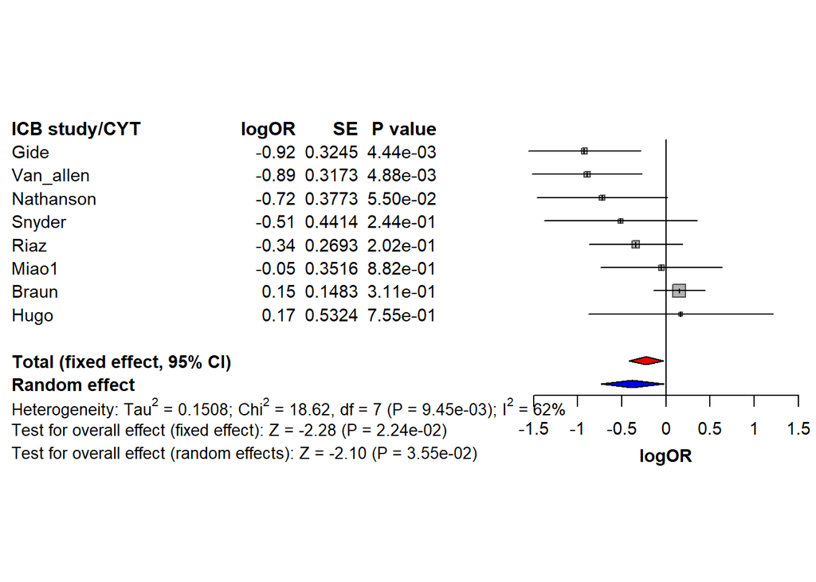

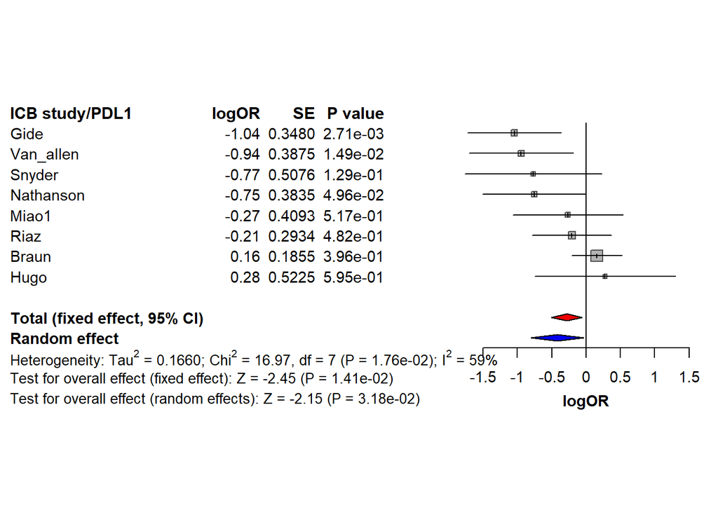